# NHL Siblings Final Report

Author

Gavin Cassidy

```r
library(tidyverse)
library(readr)
library(here)

skaters <- read.csv(here("data/skaters.csv"))

siblings <- read.csv(here("data/siblings.csv"))

siblings_full <- siblings |> pivot_longer(cols = c(sib1, sib2, sib3, sib4, sib5, sib6), names_to = "sib", values_to = "sibling", values_drop_na = TRUE)

skaters_wsib <- left_join(skaters, siblings_full, by = join_by(player == sibling))

has_sib <- skaters_wsib |> filter(!is.na(id))
no_sib <- skaters_wsib |> filter(is.na(id))
```

## Abstract

Interested in family relationships in the NHL? Which families are the most successful? This project explores sibling pairs that are the most successful in NHL history and looks for interesting trends between players with and without siblings. Is there a genetic or environmental advantage in certain families, or are NHL players without siblings better? We will combine a data set of all NHL skaters with a list of NHL siblings to find the best pairs and see if having a sibling is an advantage.

## Introduction

The modern NHL has some dynamic sibling pairs that have found themselves in the spotlight in recent history, with the Hughes brothers and Tkachuk brothers excelling during the USA Olympic victory and for their respective NHL teams. With this in mind, we decided to look into who are the best siblings in NHL history, and look deeper at those individuals. We will also look into if NHL players with siblings are better or worse than players without siblings? Siblings often compete with one another, and push eachother to be better, so will one brother motivate others to make the NHL.

NHL Statistic Descriptions:

G: Goals Scored  
A: Assists  
PTS: Points = Goals + Assists  
PIM: Penalty Minutes  
pm: Plus Minus = Team Goals Scored while on ice - Goals against while on ice  
GP: Game Played

To combine the data sets we do a left join which keeps all of the rows from our skater data while adding columns with family name and id for players who are in the sibling data. There are a few players who have the exact same name as others, especially fathers/sons, but for our most successful sibling pairs this is not an issue. Because of how the data is stored on our skater list, we cannot look at trends with fathers/sons as I initially planned because the jr. and sr. prefixes are not included in names. This contributes to skaters with the exact same names, which raises a new question, what players with the exact same name have found the most success. For example, there are 2 players named Sebastian Aho who are not related at all, and they will be compared to all other players who have the exact same name as another player. These are some of the trends and coincidences we will explore.

```r
has_sib |> slice(1, 15, 25)
```

```
         player start_year end_year position  GP  G   A PTS plus_minus PIM
1  George Allen       1939     1947     LW/D 340 82 115 197         NA 181
2 Morgan Barron       2021     2026        C 321 41  42  83         22 111
3   Jim Benning       1982     1990        D 605 52 191 243        -77 461
  even_str_G pp_G sh_G gw_G even_str_A pp_A sh_A shots_on_goal shooting_pct
1         66   14    2   15         95   20    0            NA           NA
2         36    0    5    7         38    2    2           426          9.6
3         29   21    2    5         98   91    2           799          6.5
   TOI     ATOI  OPS  DPS   PS  X Country  family id  sib
1   NA     <NA> 13.2 14.5 27.7 33  Canada   Allen 33 sib1
2 3701 11:32:00  1.7  5.3  7.0 39  Canada  Barron 39 sib1
3   NA     <NA>  9.0 26.9 35.9 44  Canada Benning 44 sib1
```

## Which siblings are the most successful?

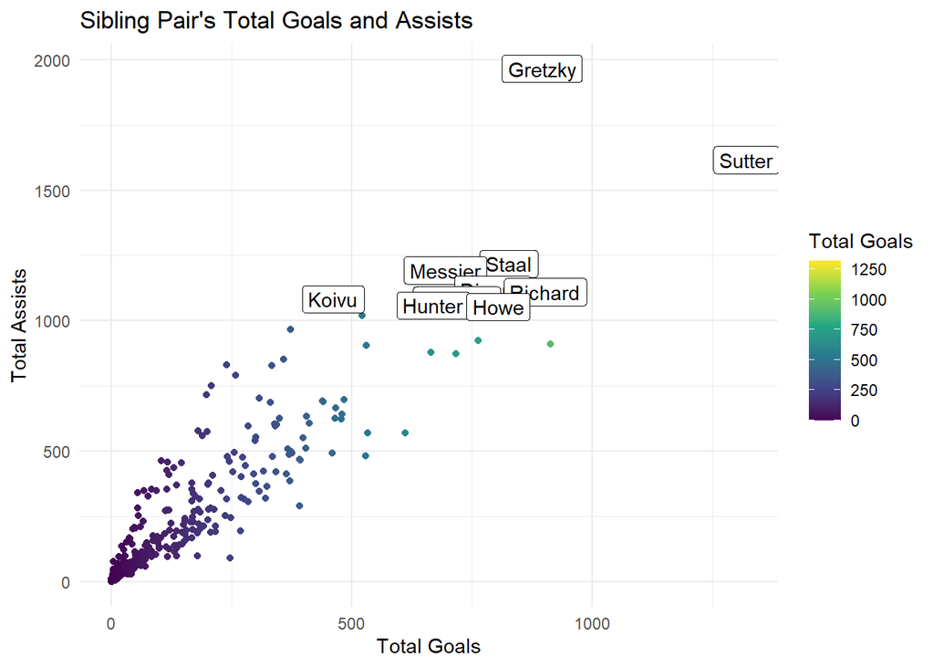

```r
g_a_sib <- has_sib |> group_by(family, id) |> summarise(tot_G = sum(G), tot_A = sum(A))

top_ten <- has_sib |> group_by(id, family) |> summarise(tot_G = sum(G), tot_A = sum(A)) |> arrange(desc(tot_A)) |> ungroup() |> slice(1:10)

ggplot(data = g_a_sib, aes(x = tot_G, y = tot_A)) +
    geom_point(aes(color = tot_G)) +
    geom_label(data = top_ten, aes(label = family)) +
    scale_color_viridis_c() +
    theme_minimal() +
    labs(x = "Total Goals", y = "Total Assists",
    title = "Sibling Pair's Total Goals and Assists",
    color = "Total Goals")
```

This plot shows the most successful sibling pairs in NHL history in terms of goals and assists. We can see that while there are a lot of sibling pairs that have acheived impressive careers, the Sutter and Gretzky siblings clearly stand above the rest. Both of these families have impressive careers rivaling some of the best individuals in NHL history.

## Gretzky and Sutter Siblings

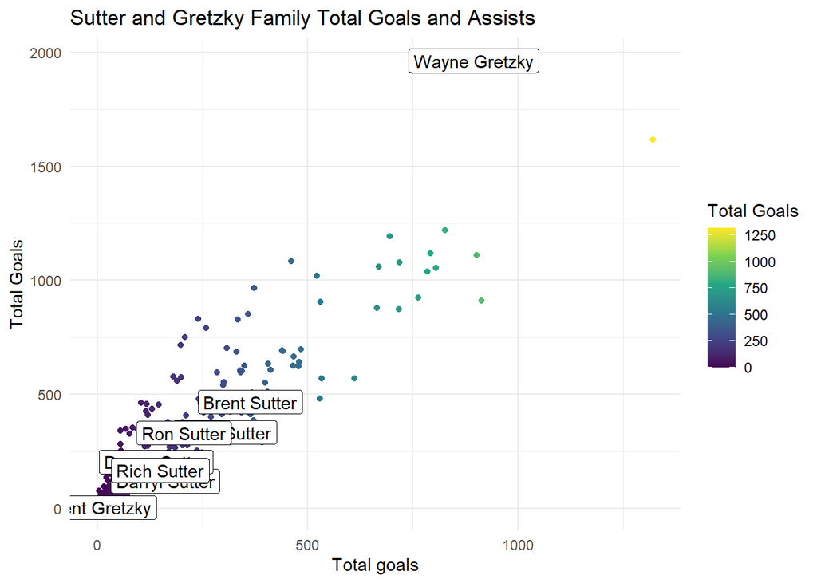

```r
gretzky <- skaters_wsib |> filter(family == "Gretzky") |> mutate(tot_G = G, tot_A = A, tot_GP = GP, tot_PIM = PIM)
sutter <- skaters_wsib |> filter(family == "Sutter") |> mutate(tot_G = G, tot_A = A, tot_GP = GP, tot_PIM = PIM)

ggplot(data = g_a_sib, aes(x = tot_G, y = tot_A)) +
    geom_point(aes(color = tot_G)) +
    geom_label(data = gretzky, aes(label = player)) +
    geom_label(data = sutter, aes(label = player)) +
    scale_color_viridis_c() +
    theme_minimal() +
    labs(x = "Total goals", y = "Total Goals",
    title = "Sutter and Gretzky Family Total Goals and Assists",
    color = "Total Goals")
```

From this plot we can see that these two families have very different collections of careers with the Sutters putting 6 siblings in the NHL, while the Gretzky family only has 2. Many hockey fans will recognize the name Wayne Gretzky, owing to his record number of Assists and Points and nickname of “The Great One”, but less will recognize his brother Brent Gretzky in the bottom left of our plot. Brent played 13 games with in the NHL, totaling 4 PTS, while Wayne carries the pair with 2857 PTS. The Sutters have 6 siblings, all of whom played at least 400 games, and totaling immense numbers of goals and assists.

## Most Penalty Minutes

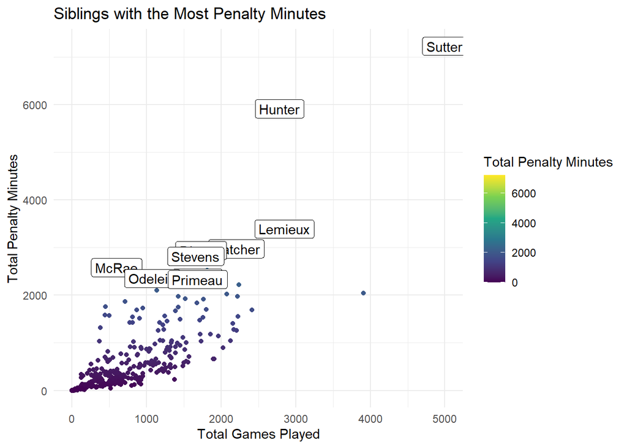

```r
pim_sib <- has_sib |> group_by(id, family) |> summarise(tot_PIM = sum(PIM), tot_GP = sum(GP))

top_pim <- has_sib |> group_by(family) |> summarise(tot_PIM = sum(PIM), tot_GP = sum(GP)) |> arrange(desc(tot_PIM)) |> slice(1:10)

ggplot(data = pim_sib, aes(x = tot_GP, y = tot_PIM)) +
    geom_point(aes(color = tot_PIM)) +
    geom_label(data = top_pim, aes(label = family)) +
    scale_color_viridis_c() +
    theme_minimal() +
    labs(x = "Total Games Played",
    y = "Total Penalty Minutes",
    title = "Siblings with the Most Penalty Minutes",
    color = "Total Penalty Minutes")
```

This plot shows another side of siblings, instead of goals and assists we are looking at Penalty Minutes. In Hockey, most penaltys are 2 minutes, while the more violent miscondut like fighting is 10 minutes. This means to accumulate more penalty minutes, players will tend to get in fights, as well as accumulating lots of other penalties. Here we can see the the Hunter brothers have an impressive amount of penalty minutes considering their number of games player, while the Sutter brothers have a crazy number of games played and penalty minutes.

## Which of these siblings is the most violent?

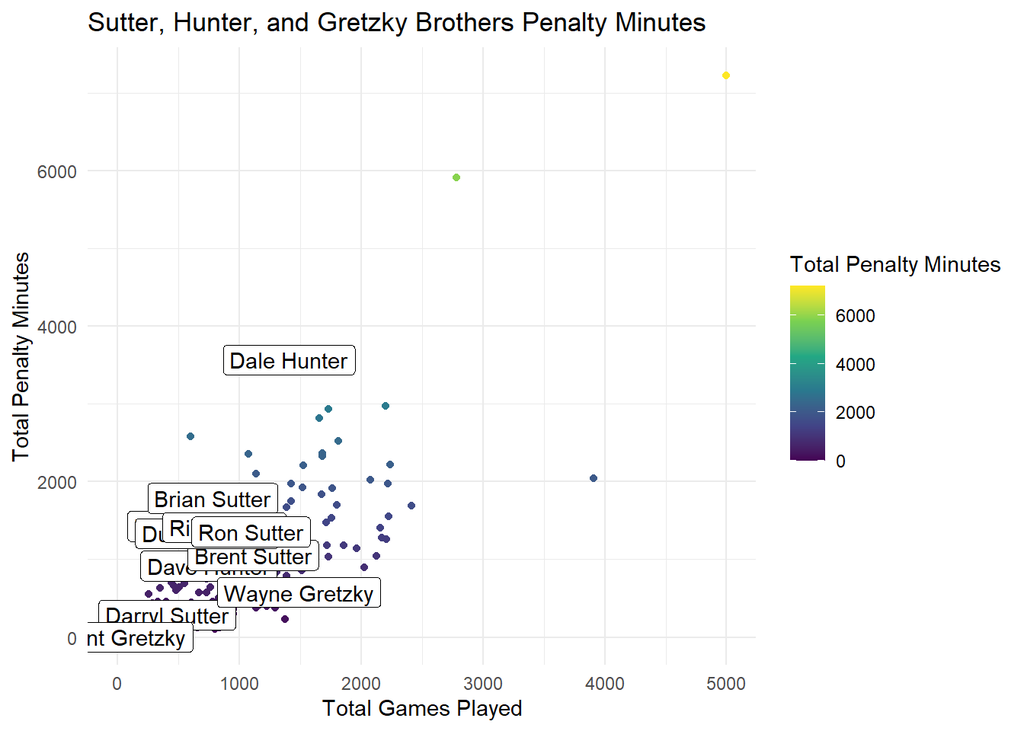

```r
hunter <- skaters_wsib |> filter(family == "Hunter") |> mutate(tot_GP = GP, tot_PIM = PIM)

ggplot(data = pim_sib, aes(x = tot_GP, y = tot_PIM)) +
    geom_point(aes(color = tot_PIM)) +
    geom_label(data = hunter, aes(label = player)) +
    geom_label(data = sutter, aes(label = player)) +
    geom_label(data = gretzky, aes(label = player)) +
    scale_color_viridis_c() +
    theme_minimal() +
    labs(x = "Total Games Played",
    y = "Total Penalty Minutes",
    color = "Total Penalty Minutes",
    title = "Sutter, Hunter, and Gretzky Brothers Penalty Minutes")
```

On this plot we can see that Dale Hunter’s brothers must have had a tough time growing up, with him contributing by far the most penalty minutes. The Sutter brothers also all produce a solid number of penalty minutes, and are overwhelming in their numbers, I feel for their parents who undoubtedly broke up a good amount of roughhousing. The Wayne Gretzky shows that he was more artful than violent on the ice, accumulating significantly less penalty minutes than players with the same number of games.

## Per-Player Siblings vs. Non-Siblings Statistics

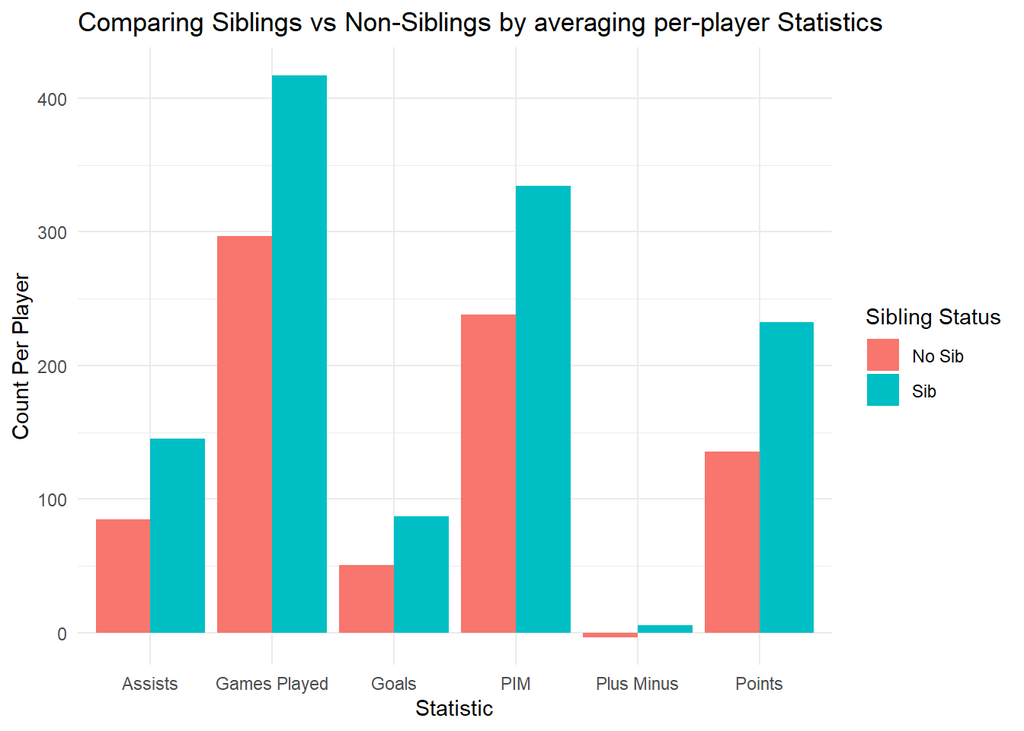

```r
sib_comp_per_player <- skaters_wsib |> mutate(sib_ind = if_else(!is.na(id), "Sib", "No Sib")) |>
    group_by(sib_ind) |> filter(!is.na(PIM)) |> filter(!is.na(plus_minus)) |>
    summarise("Games Played" = sum(GP)/n(),
    Goals = sum(G)/n(),
    Assists = sum(A)/n(),
    Points = sum(PTS)/n(),
    PIM = sum(PIM)/n(),
    "Plus Minus" = sum(plus_minus)/n()
    ) |>
        pivot_longer(cols = c(`Games Played`, Goals, Assists, Points, PIM, `Plus Minus`))

ggplot(data = sib_comp_per_player, aes(x = name, y = value, fill = sib_ind)) +
    geom_col(position = "dodge") +
    theme_minimal() +
    labs(x = "Statistic", y = "Count Per Player", fill = "Sibling Status",
    title = "Comparing Siblings vs Non-Siblings by averaging per-player Statistics")
```

## Per-Game Siblings vs. Non-Siblings Statistics

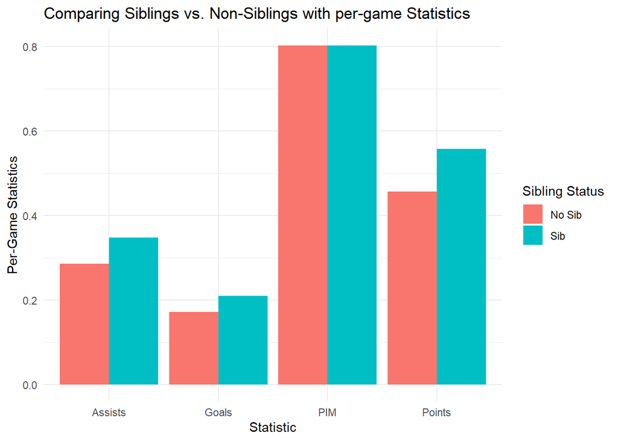

```r
sib_comp_per_game <- skaters_wsib |> mutate(sib_ind = if_else(!is.na(id), "Sib", "No Sib")) |>
    group_by(sib_ind) |> filter(!is.na(PIM)) |> filter(!is.na(plus_minus)) |>
    summarise(Goals = sum(G)/sum(GP),
    Assists = sum(A)/sum(GP),
    Points = sum(PTS)/sum(GP),
    PIM = sum(PIM)/sum(GP),
    ) |>
        pivot_longer(cols = c(Goals, Assists, Points, PIM))

ggplot(data = sib_comp_per_game, aes(x = name, y = value, fill = sib_ind)) +
    geom_col(position = "dodge") +
    theme_minimal() +
    labs(x = "Statistic", y = "Per-Game Statistics",
    fill = "Sibling Status",
    title = "Comparing Siblings vs. Non-Siblings with per-game Statistics")
```

This plot shows how well siblings vs. non-siblings perform per-game on average. We can see that players with NHL siblings are better in Goals, Assists, and Points per game, showing that they produce more than players without siblings in the NHL. This and our previous plot tell us that players with siblings in the NHL are better than players without NHL siblings and tend to have longer careers.

## Players with the same name

During this project I stumbled on a collection of players who had the exact same name as other NHL players. Some of these are father-son pairs, with Jr. and Sr. prefixes not featured on Hockey Reference, while others just coincedentally have the same exact names. This next section will see which pair of players with the same name has been the most successful.

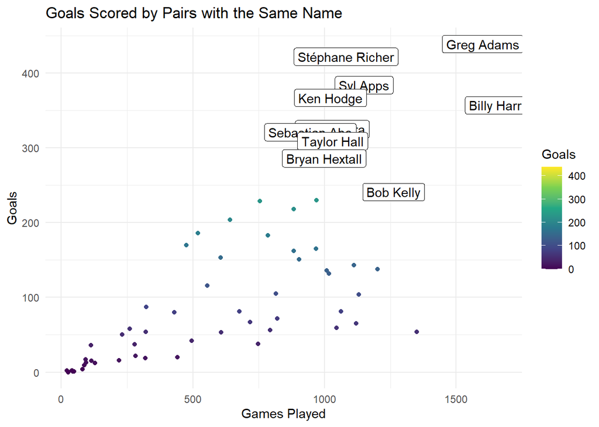

```r
same_name <- skaters |> group_by(player) |> mutate(size = n()) |> filter(size > 1) |>
    mutate(plus_minus = if_else(!is.na(plus_minus), plus_minus, 0, 0)) |>
    summarise(G = sum(G), A = sum(A), GP = sum(GP), PTS = sum(PTS),
    plus_minus = sum(plus_minus), PIM = sum(PIM))

same_name_topg <- same_name |> arrange(desc(G)) |> slice(1:10)

ggplot(data = same_name, aes(x = GP, y = G)) +
    geom_point(aes(color = G)) +
    scale_color_viridis_c() +
    geom_label(data = same_name_topg, aes(label = player)) +
    theme_minimal() +
    labs(x = "Games Played", y = "Goals",
    color = "Goals", title = "Goals Scored by Pairs with the Same Name")
```

This plot shows the top performing pairs of people who have the same exact name. We see players like Syl Apps Sr. and Jr., the former which was one of the greatest Centers of all time. His son would later go on to play and have a solid NHL career as well. This is contrasted with players like Sebastian Aho, with 2 players from the 2000s-2010s and coming from different countries (Sweden and Finland). The top scoring pair, Greg Adams and Greg Adams, played 10 years apart and had no relation beside the same name. It was interesting to see a number of players who had no relation with solid success in the NHL.

## Most Violent Players with the same name

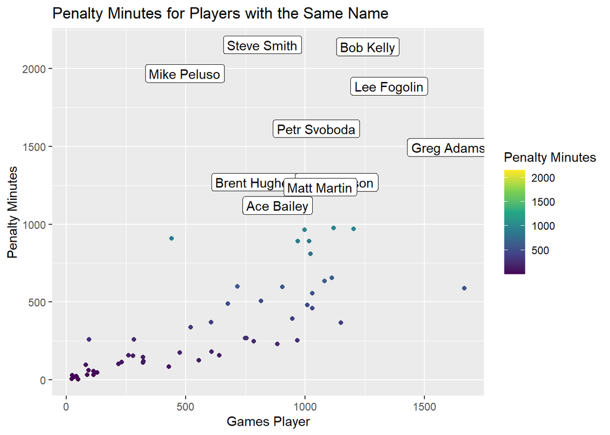

```r
same_name_toppim <- same_name |> arrange(desc(PIM)) |> slice(1:10)

ggplot(data = same_name, aes(x = GP, y = PIM)) +
    geom_point(aes(color = PIM)) +
    scale_color_viridis_c() +
    geom_label(data = same_name_toppim, aes(label = player)) +
    labs(x = "Games Player", y = "Penalty Minutes", color = "Penalty Minutes",
    title = "Penalty Minutes for Players with the Same Name")
```

Steve Smith and Steve Smith are the most violent pair, and while not related they have over 2000 Penalty Minutes combined. However, 1 of the two only played 17 games and has less than 20 PIM. The list features other known enforcers like Mike Peluso, Steve Smith, and Bob Kelley. I was hoping that violence would run in the family for some Jr. and Sr. pairs, but it appears that most of our top name sharing partners are unrelated.

## Conclusion

From this project, we discovered that players with siblings in the NHL tend to be stronger players, with more production and longer careers. This indicates that having a sibling is an advantage, either by bringing a higher level of competition earlier, or shows that certain families have better genetics or nuture athletes in a better way. We can also see certain families that thrived in the NHL, like Sutters. There were interesting trends, with Wayne Gretzky contributing enough production for 2 careers, and Dale Hunter showing his violent tendincies. Discovering the trends of players with the same names was also interesting with a lot less father-son combinations than I expected. In the future, I would love to see trends between father-son pairs, but the format of hockey reference names makes it impossible to distinguish between the names, as the suffixes are not included. This was a challenge I encountered while exploring data. Some limitiations in the visualization are that most of the points are anonymous, with too many names being difficult to visualize and a dynamic visualization making the reader’s experience unknown.

Ideally there would be an app to visualize different combinations of statistics with optional labeling and a hover to display names if desired. More time would make this doable.